# R Notebook

# PCA y Clustering

```r
library(readr)
CLEAN_P <- read_csv("CLEAN_P.csv")
```

## Análisis de componentes principales

Para aplicar componentes principales tenemos que hacerle 3 pruebas a nuestra base de datos:

### 1- Prueba de correlaciones

```r
cor(CLEAN_P)
```

```
                       country         year         sex           age  suicides_no   population
country           1.000000e+00  0.022769229  0.00000000  2.535676e-05  0.118555466  0.158896057
year              2.276923e-02  1.000000000  0.00000000 -5.858810e-04 -0.004545958  0.008850170
sex               0.000000e+00  0.000000000  1.00000000  0.000000e+00  0.144629174 -0.011242080
age               2.535676e-05 -0.000585881  0.00000000  1.000000e+00 -0.018256260 -0.093361482
suicides_no       1.185555e-01 -0.004545958  0.14462917 -1.825626e-02  1.000000000  0.616162268
population        1.588961e-01  0.008850170 -0.01124208 -9.336148e-02  0.616162268  1.000000000
suicides/100k pop 5.522414e-02 -0.039036797  0.39149647  1.872146e-01  0.306604451  0.008284973
gdpforyear        1.635832e-01  0.094528572  0.00000000  6.084189e-05  0.430095852  0.710697323
gdppercapita      5.334082e-02  0.339134280  0.00000000 -1.567976e-04  0.061329749  0.081509858
generation        6.068990e-03  0.268300577  0.00000000  2.148529e-01 -0.070623705 -0.067962605
                  suicides/100k pop   gdpforyear  gdppercapita  generation
country                 0.055224141 1.635832e-01  0.0533408202  0.00606899
year                   -0.039036797 9.452857e-02  0.3391342801  0.26830058
sex                     0.391496466 0.000000e+00  0.0000000000  0.00000000
age                     0.187214622 6.084189e-05 -0.0001567976  0.21485290
suicides_no             0.306604451 4.300959e-01  0.0613297488 -0.07062371
population              0.008284973 7.106973e-01  0.0815098582 -0.06796261
suicides/100k pop       1.000000000 2.523964e-02  0.0017851338 -0.04982007
gdpforyear              0.025239644 1.000000e+00  0.3034045356  0.02125070
gdppercapita            0.001785134 3.034045e-01  1.0000000000  0.08289921
generation             -0.049820070 2.125070e-02  0.0828992106  1.00000000
```

Es difícil identificar las correlaciones entre variables, así que veámoslo en una grafica

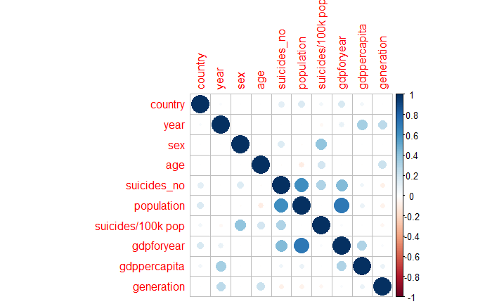

```r
library(corrplot)
corrplot(cor(CLEAN_P))
```

Entre mas pintados estén los círculos las variables tendrán mejor correlación

### 2- Prueba de Barlett

Para contrastar la igualdad de las varianzas (homocedasticidad).

```r
library(psych)
cortest.bartlett(cor(CLEAN_P),n=345)
```

```
$chisq
[1] 682.9361

$p.value
[1] 6.613039e-115

$df
[1] 45
```

### 3- Prueba KMO

```r
KMO(CLEAN_P)
```

```
Kaiser-Meyer-Olkin factor adequacy
Call: KMO(r = CLEAN_P)
Overall MSA =  0.57
MSA for each item =
          country              year               sex               age       suicides_no        population
             0.88              0.54              0.55              0.43              0.65              0.56
suicides/100k pop        gdpforyear      gdppercapita        generation
             0.47              0.61              0.49              0.51
```

Nuestros resultados nos indican que se justifica la realizacion del PCA, ya que, nuestro valor MSA es de 0.57, si fuera menor de 0.5 no se podria realizar el PCA.

## Gráficos de sedimentación

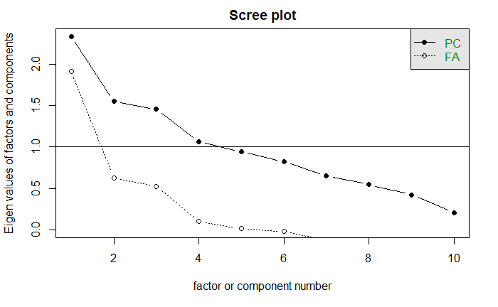

```r
scree(CLEAN_P)
```

La grafica anterior nos muestra los componentes y traza una línea referencial para que nos ayude a tomar los componentes necesarios para nuestro análisis, en nuestro caso los que tomaríamos son los que están arriba de la línea horizontal que son 4, pero corroboremos que esto es cierto con otro grafico

```
Parallel analysis suggests that the number of factors =  NA  and the number of components =  4
```

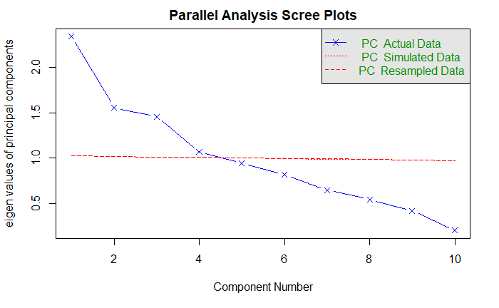

```r
fa.parallel(CLEAN_P, fa="pc" )
```

Nos confirma que si se tienen que tomar 4 componentes.

```r
componentes = prcomp(CLEAN_P, scale= TRUE, center=TRUE)
summary(componentes)
```

```
Importance of components:
                          PC1    PC2    PC3    PC4    PC5     PC6     PC7     PC8     PC9    PC10
Standard deviation     1.5291 1.2469 1.2064 1.0332 0.9721 0.90489 0.80538 0.73780 0.64914 0.45405
Proportion of Variance 0.2338 0.1555 0.1456 0.1067 0.0945 0.08188 0.06486 0.05444 0.04214 0.02062
Cumulative Proportion  0.2338 0.3893 0.5348 0.6416 0.7361 0.81795 0.88281 0.93725 0.97938 1.00000
```

Este análisis nos devuelve una matriz de datos, veamos la proporción acumulada, en el componente 4 podemos ver que tiene un acumulado de 0.6416 lo que nos termina de confirmar que el haber tomado 4 componentes fue la mejor opción.

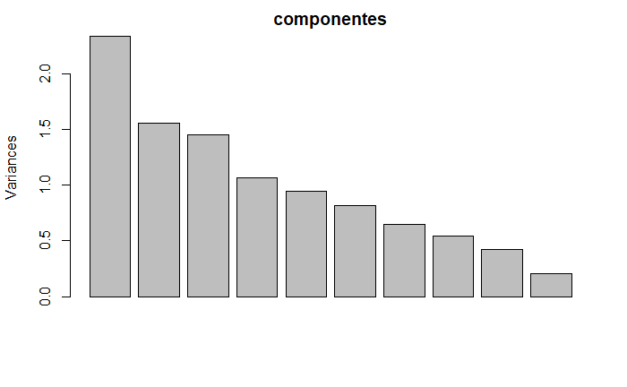

```r
plot(componentes)
```

## Graficamos los componentes

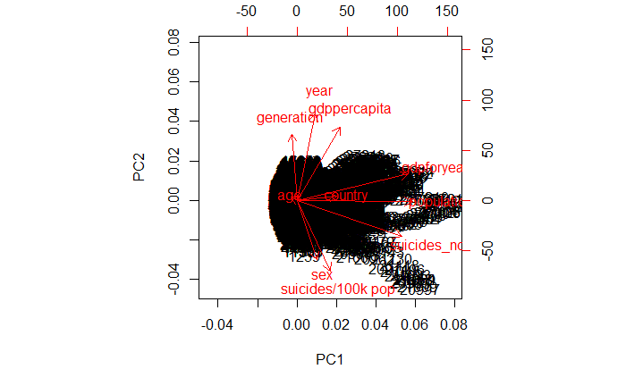

```r
biplot(componentes,scale=1)
```

Lo anterior nos da una aproximación a la distribución de una muestra multivariante en un espacio de dimensión reducida

## Extraemos los componentes

```r
componentes_prin = componentes$x
componentes_prin = componentes_prin[,1:4]
head(componentes_prin)
```

```
           PC1        PC2         PC3        PC4
[1,] -1.066594 -1.6833853 -1.04211840 -1.0120694
[2,] -1.159099 -0.9688505  0.07001274  0.3244710
[3,] -1.285721 -0.9291777 -2.00232155 -0.2312577
[4,] -1.204948 -1.7970522 -0.01322522  0.7272554
[5,] -1.095636 -2.0318521 -1.30298101 -0.9868157
[6,] -1.413930 -1.0468099 -0.97268560  1.5092660
```

# Clustering

```r
scale_datos = scale(CLEAN_P)
library(cluster)
library(factoextra)
```

## Algoritmo de CLARA

Clara es un algoritmo de partición, se utiliza cuando el conjunto de datos es muy grande (miles de observaciones) con el fin de reducir el tiempo de computación y problemas en el almacenamiento de la RAM.

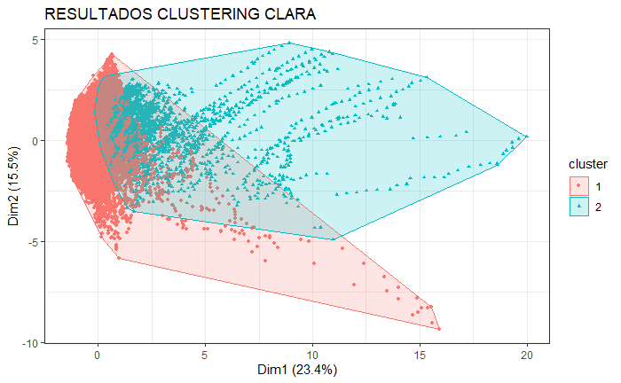

```r
clara_cluster = clara(CLEAN_P,2)
fviz_cluster(clara_cluster,stand = T,geom = "point",pointsize = 1)+
  theme_bw() +
  labs(title = "RESULTADOS CLUSTERING CLARA")
```

## Validación

|  | cluster | size | ave.sil.width |
| --- | --- | --- | --- |
| 1 | 1 | 42 | 0.92 |
| 2 | 2 | 2 | 0.94 |

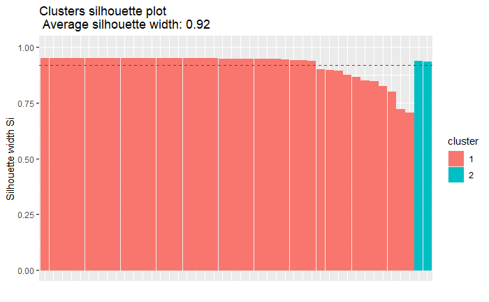

```r
fviz_silhouette(clara_cluster)
```

Un valor de Si cercano a 1 indica que el objeto está bien agrupado, en otras palabras el objeto i es similar a los otros objetos de su grupo, por otro lado, un valor Si cercano a -1 indica que el objeto está mal agrupado y que probablemente si se asignara a otro clúster los resultados mejorarían.

Para finalizar, agreguemos a nuestros datos el vector clustering, para tener un control de en qué clúster quedo cada dato.

```r
Clustering = clara_cluster$clustering
datos = data.frame(cbind(CLEAN_P, Clustering))
head(datos)
```

|  | country | year | sex | age | suicides_no | population | suicides.100k.pop | gdpforyear | gdppercapita | generation | Clustering |
| --- | --- | --- | --- | --- | --- | --- | --- | --- | --- | --- | --- |
| 1 | 0 | 1987 | 1 | 0 | 21 | 312900 | 6.71 | 2156624900 | 796 | 2 | 1 |
| 2 | 0 | 1987 | 1 | 2 | 16 | 308000 | 5.19 | 2156624900 | 796 | 5 | 1 |
| 3 | 0 | 1987 | 0 | 0 | 14 | 289700 | 4.83 | 2156624900 | 796 | 2 | 1 |
| 4 | 0 | 1987 | 1 | 5 | 1 | 21800 | 4.59 | 2156624900 | 796 | 1 | 1 |
| 5 | 0 | 1987 | 1 | 1 | 9 | 274300 | 3.28 | 2156624900 | 796 | 0 | 1 |
| 6 | 0 | 1987 | 0 | 5 | 1 | 35600 | 2.81 | 2156624900 | 796 | 1 | 1 |